[figure not shown]

Analyzing and Modeling Kickstarter Data: What are the drivers of success for Kickstarter campaigns?

# Introduction

## What is Kickstarter?

Kickstarter, founded in 2009, is an online crowdfunding platform. Their mission is to help “bring creative projects to life” (Kickstarter, 2009) as individuals can create projects that draw others to support the process.

Through the platform, creators can select from a variety of categories to best represent their project topic, set a campaign length, and set a funding goal, among other campaign descriptors. Essentially, creators have full control of how they present their vision to others. If a project is promising, backers—people who support a project—can pledge any amount of money to support the process. Creators can also set rewards to backers who pledge certain amounts of money. If the project does not reach its goal by the end of the campaign length, no money is lost. But if a project is successful, the funds go to bringing the project to fruition.

## What was our motivation?

As more individual and creative projects are soaring, we wanted to analyze the trend of Kickstarter projects throughout the years and determine if we could predict the probability of success of a launched project. Ultimately, we want to understand what factors go into making a successful campaign, if any. For anyone wanting to launch a campaign of their own, this blog is intended to support prospective creators in the process. From writing a strong project description to determining the best launch day, we want to inspire creators as they embark on their creative endeavors.

## How did we get the data?

A company called [Web Robots](https://webrobots.io/kickstarter-datasets/) has a web crawler that scrapes data from [Kickstarter’s website](https://www.kickstarter.com/) every month. We aggregated 58 csv files that were scraped by their web crawler in December of 2020. Since the columns are the same across csv files, we simply read in all of the csv files and bound the rows together.

```r
# get the name of the folder containing the Kickstarter csv files
root <- "kickstarter_raw_data"
# get the names of all of the Kickstarter csv files
files <- dir(root, pattern='csv$', recursive = TRUE, full.names = TRUE)
# read in all of the csv files and bind them to a data frame
all_data <- files %>%
  map_dfr(read_csv)
```

Once we had all the data in a single data frame, we could start making visualizations and models, right? Well… not so fast. There was a substantial amount of data wrangling and cleaning that had to be done before we could get to the fun stuff. Our initial csv file had 213,564 Kickstarter campaigns with 24,135 duplicates.

After removing the duplicate campaigns, we filtered for only the campaigns that succeeded or failed, removing those that were ongoing, suspended, or canceled. We also fixed various issues in the columns of the data set, such as inconsistencies in the conversion of the goal and pledged amounts to USD, an inaccurate country column, and a JSON formatted category column, just to name a few. After cleaning the data, we were left with 170,536 Kickstarter campaigns in our data frame. If you like digging into data and are eager to learn more about our data wrangling process, please check out the [code](https://github.com/stat231-f21/blog_data-diggers/blob/079c15b0d7ad6721d54d129b0aa8c50ac8eb18f6/data-wrangling.Rmd) on github.

# Success by State and Category

[interactive chart not shown]

The interactive table makes it easy to compare the success rates of the 15 Kickstarter categories in all states or a specific US state. It ranks the Kickstarter categories based on their success rates in descending order. For all US states, comic book projects have the highest success rate with over 87% of comic book campaigns reaching their funding goal. On the other hand, journalism projects have the lowest success rate in all US states, with a measly 24% of projects reaching their funding goal.

To compare success rates for a specific category across states, we can use the map and select a category. Darker states have higher success rates in the selected category. For all categories, campaigns in Vermont, Massachusetts, and New York have the highest success rates while campaigns in South Dakota, Florida, and Mississippi have the lowest success rates. If we select Photography as a category for example, we can see that Nevada has the highest success rate by far, since it is a much darker shade of green than the other states. This may be explained by Nevada being home to the [Burning Man Festival](https://en.wikipedia.org/wiki/Burning_Man), for which successful Photography campaigns like [this](https://www.kickstarter.com/projects/zippylomax/dusty-playground?ref=discovery_category_most_funded&term=burning%20man) are centered around.

# Text Analysis of Kickstarter Names and Blurbs

## Text Length and Outcome

### Name Length

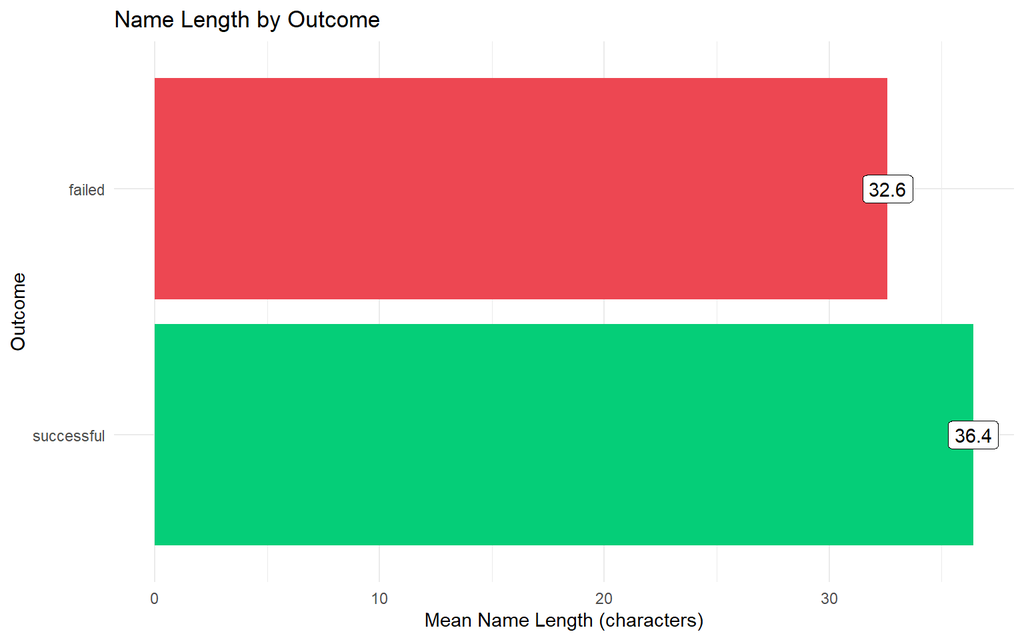

### Blurb Length

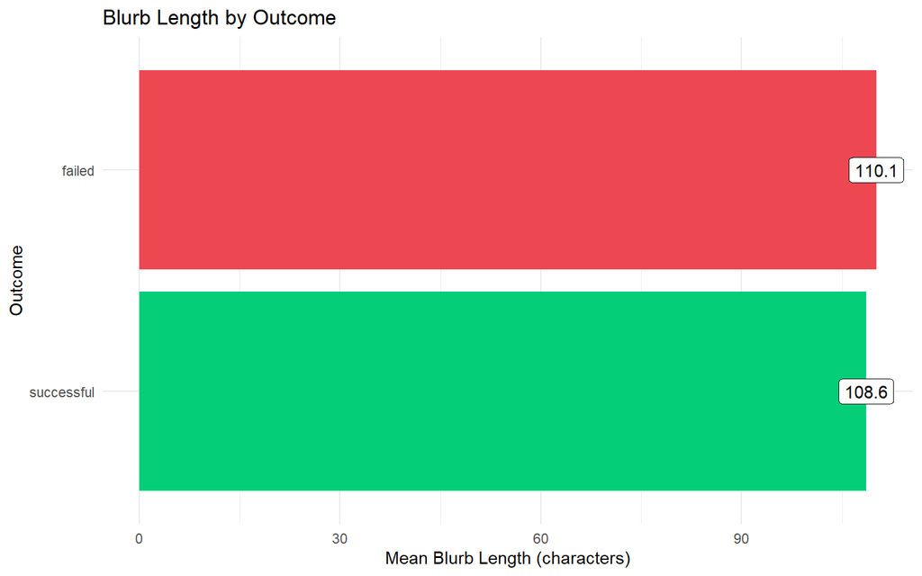

## Sentiment Analysis of Kickstarter Blurbs

```r
# get Bing sentiment scores
bing_scores <- blurb_sentiment_bing %>%
  group_by(name, outcome) %>%
  summarize(
    sentiment_score = sum(sentiment == "positive") -
      sum(sentiment == "negative")
    )
# get Afinn sentiment scores
afinn_scores <- blurb_sentiment_fin %>%
  group_by(name, outcome) %>%
  summarize(sentiment_score = sum(value))
```

### Bing Lexicon

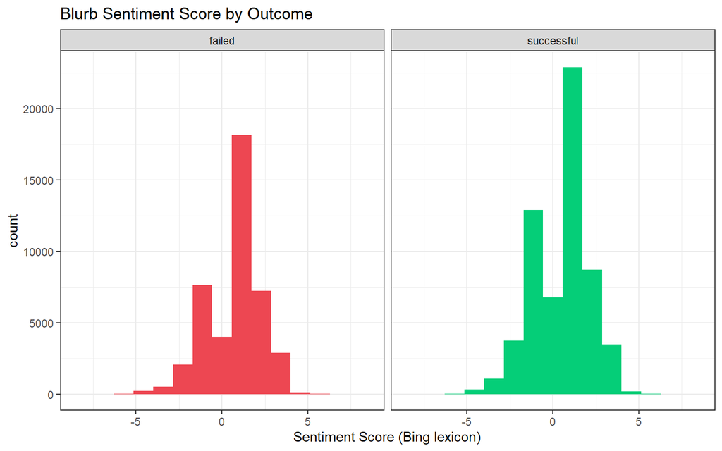

| Outcome | Mean Sentiment Score |
| --- | --- |
| failed | 0.664 |
| successful | 0.458 |

### Afinn Lexicon

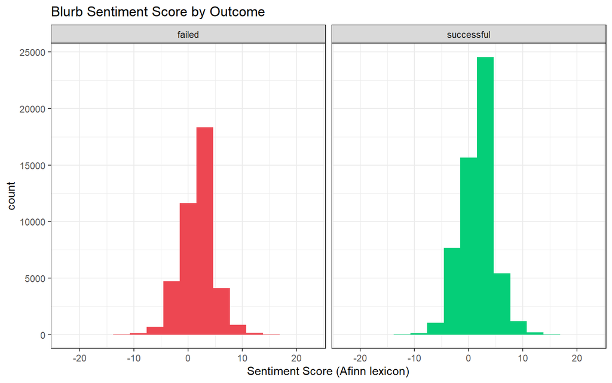

| Outcome | Mean Sentiment Score |
| --- | --- |
| failed | 1.708 |
| successful | 1.537 |

## Comparison Word Cloud of Kickstarter Blurbs

[interactive chart not shown]

# Univariate Analysis of Potential Predictors

This section examines both the categorical and quantitative variables that describe the Kickstarter campaigns in our data set. We analyze variables that are known when the campaign is first launched and could potentially be used to predict a campaign’s chance of reaching its goal. We don’t include amount funded as a potential predictor since it is not known until after the campaign ends. Selected categorical variables include staff pick status, launch day, launch month, launch year, and category. Quantitative variables are campaign length and goal size.

## Categorical Variables

### Bar Graphs

#### Staff Pick

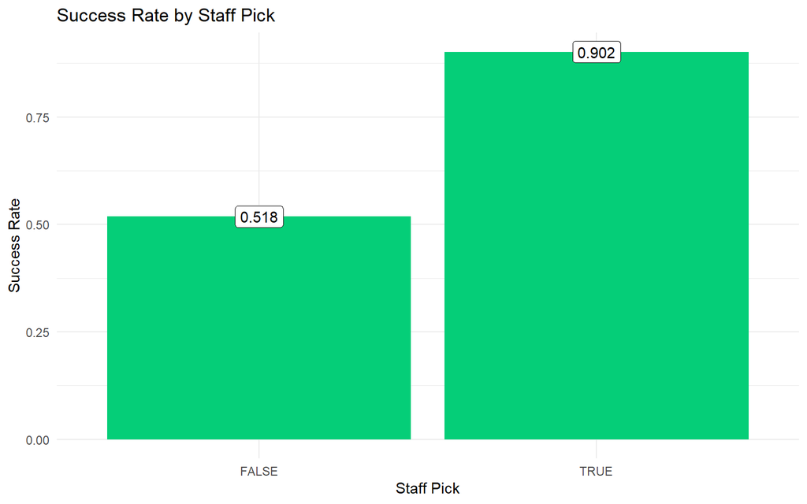

#### Launch Day

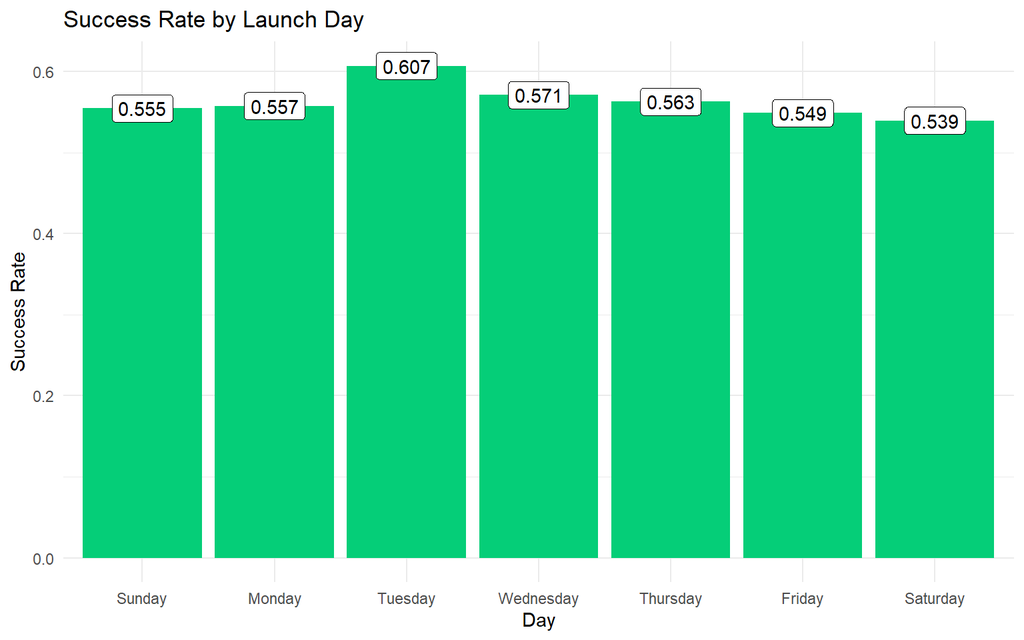

#### Launch Month

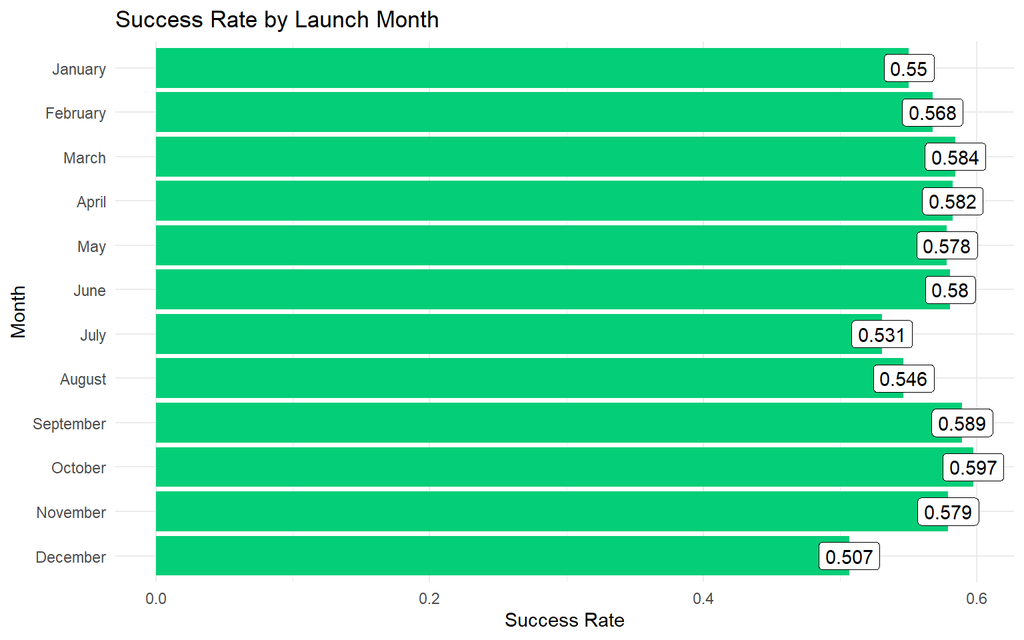

#### Category

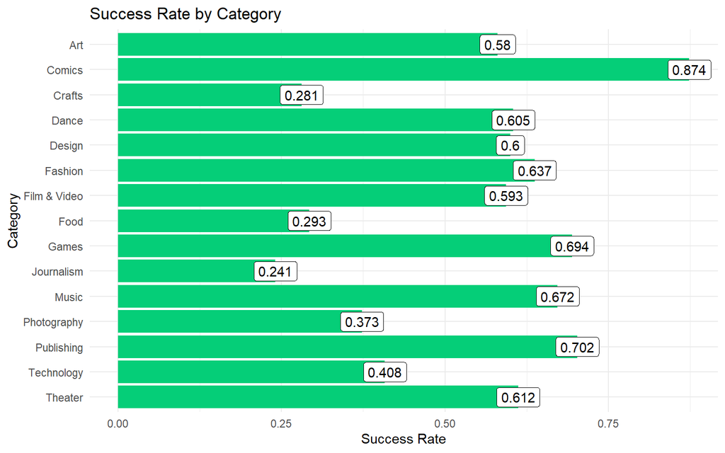

- Staff Pick: 51.8% of campaigns that were not staff picks were successful, while 90.2% of campaigns that were staff picks were successful.
- Launch Day: Tuesday is the best day to launch a campaign, as 60.7% of campaigns launched on Tuesday were successful. Saturday is the worst, since only 53.9% of campaigns launched on that day were successful.
- Launch Month: October is the best month to launch a campaign, as 59.7% of campaigns launched in October were successful. December is the worst, since only 50.7% of campaigns launched in December were successful.
- Category: The top 3 categories were comics, publishing, and games: 87.4% of comic campaigns were successful, 70.2% of publishing campaigns were successful, and 69.4% of game campaigns were successful. The bottom 3 categories were Journalism, Crafts, and Food: 24.1% of journalism campaigns were successful, 28.1% of craft campaigns were successful, and 29.3% of food campaigns were successful.

### Year

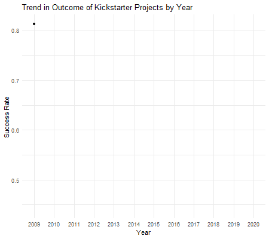

Animated with the `gganimate` package, the above time series plot shows that the success rates of Kickstarter campaigns in its early years remained constant at above a 75% success rate. However, after 2013, there was a significant dip from 80% to a whopping 44% success rate by 2015. So how do we explain this drop in the trend of successful campaigns from 2013-2015?

Laura Lewis, an Amazon data scientist who examined Kickstarter success trends throughout the years, created a time series plot with the total number of launched projects each year from 2009-2019. She found that by 2014, Kickstarter saw a significant rise in campaigns with a peak of over 4000 projects launched in 2014 (Lewis, 2019). Thus, the proportion of successful projects decreased as the number of launched projects increased. Nevertheless, the site has seen considerable improvement in success rates in recent years while the number of launched projects have remained fairly constant since 2016.

## Quantitative Variables

### Campaign Length

From 2009-2011, Kickstarter creators were able to set campaign lengths of up to 90 days. However, in 2011, Kickstarter claimed that through their own research, they found that projects lasting longer than 60 days were less successful than projects with shorter campaign lengths, Thus, after 2011, campaign lengths were recommended to be at most 30-60 days (Strickler, 2011).

In this section, we analyze the validity of Kickstarter’s findings: Do shorter campaign lengths correlate with higher success rates on Kickstarter projects?

#### 2011

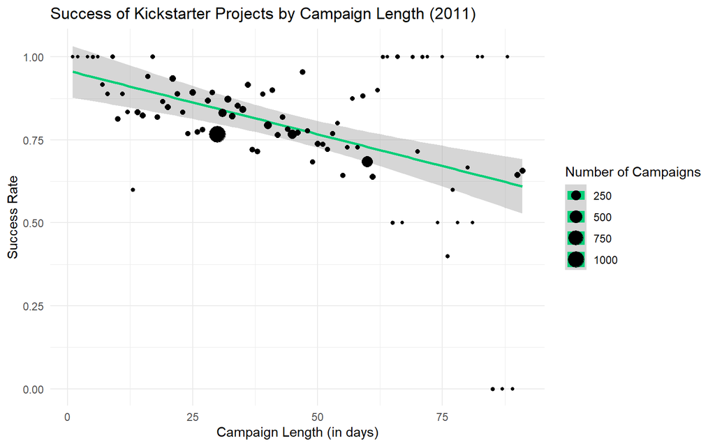

#### 2012-2020

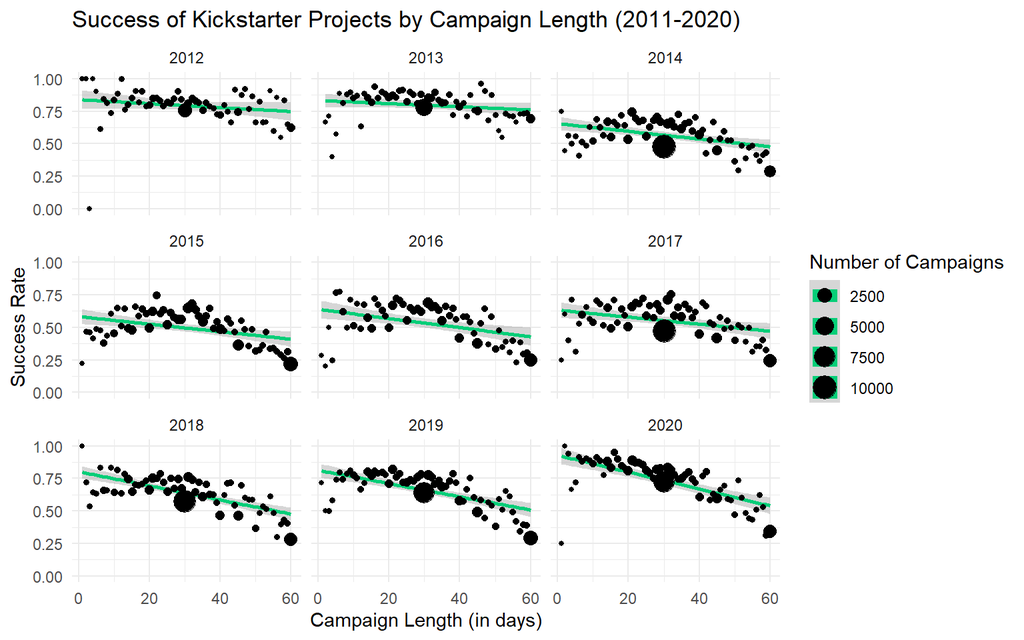

In 2011, a year prior to the change in campign length, there is a moderately strong, negative, and roughly linear association between campaign length and success rate. So as the campaign length increases, the success rate decreases.

In the multi-panel plot, created with the `facet_wrap()` function, we see this trend from 2011 continue as the number of campaigns begin to increase significantly. Most of the campaigns in 2012-2020 set a campaign length of approximately 30 days and are more successful than campaigns with much longer campaign lengths. We predict this is because 30 days suggests a greater level of urgency for a project to be backed, especially if it is something that prompts a lot of interest. Meanwhile, shorter campaign lengths generally do not give projects enough time to reach a larger audience of backers to pledge the necessary amount for the campaign goal to be reached.

### Goal Size

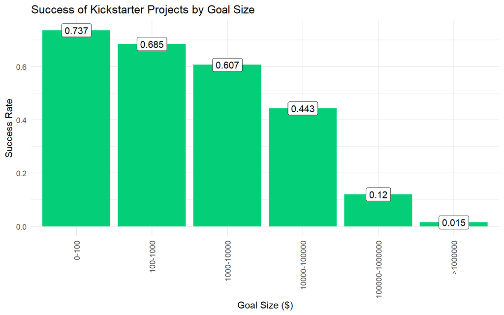

# Multivariable Thinking With a Logistic Regression Model

## Train-Test Split

```r
sample <- sample(c(TRUE, FALSE), nrow(kickstarter_subset),
                 replace = TRUE, prob = c(0.7,0.3))
train <- kickstarter_subset[sample, ]
test <- kickstarter_subset[!sample, ]
```

## Conditions for Logistic Regression

- Is outcome binary? Yes outcome is binary since a Kickstarter campaign can either have a failed or successful outcome.
- Linearity: Checked for quantitative predictors below, automatic for categorical predictors.
- Independence of observations: It is reasonable to assume that Kickstarter campaigns independent.
- Randomness: We know that we didn’t capture all Kickstarter campaigns from 2009-2020, but we will assume that the 170,000 scraped campaigns are a random subset of the population.

## EDA

### Response Variable - Kickstarter Campaign Outcome

| Outcome | Number of Campaigns | Frequency of Campaigns |
| --- | --- | --- |
| Failed | 51354 | 0.4307 |
| Successful | 67884 | 0.5693 |

56.9% of all Kickstarter campaigns in the training set were successful.

### Quantitative Predictors - Check Linearity of Predictors and log-odds

#### Goal

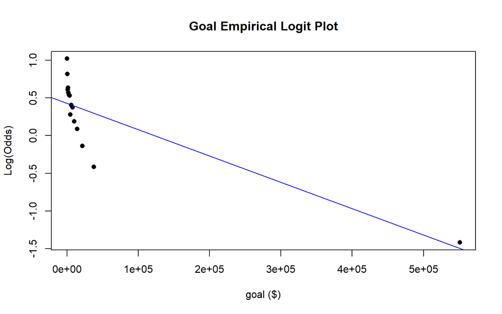

#### Sqrt(Goal)

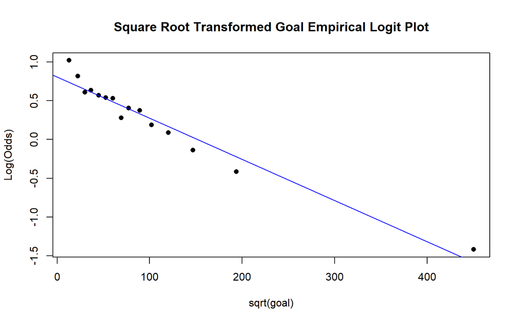

#### Name Length

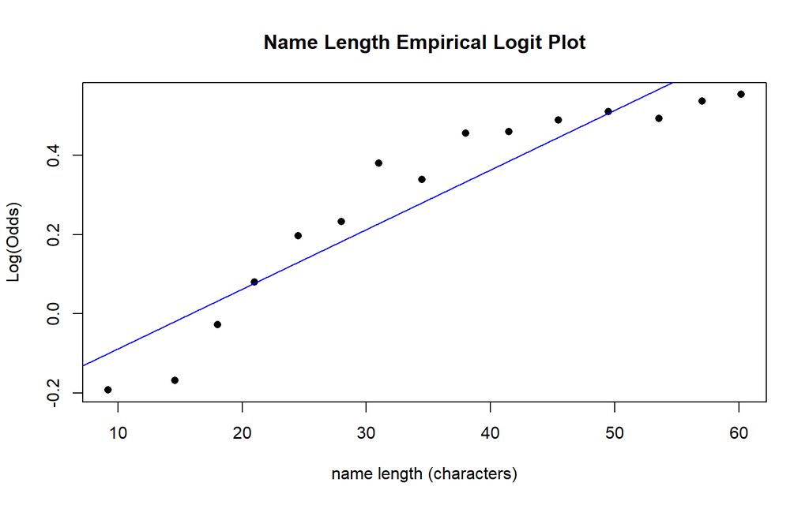

#### Campaign Length

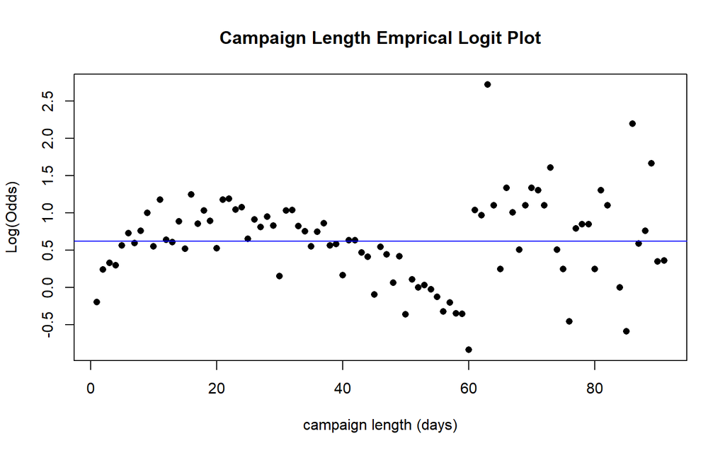

Funding goal does not initially have a linear relationship with the log odds of the outcome, so we applied a square root transformation. A square root transformation will inflate smaller goals and stabilize larger ones, which is helpful here because of the right skewed distribution of Kickstarter goals. The name length has a linear relationship with the log odds of the outcome. The empirical logit plot for the campaign length looks concerning in terms of both linearity and strength of the relationship.

## Model Fitting

```r
mod.full <- glm(outcome ~ sqrt_goal_usd + name_length + campaign_length +
                  staff_pick + launch_day + launch_month +
                  main_category, data = train, family = "binomial")
mod.small <- glm(outcome ~ sqrt_goal_usd + name_length +
                   campaign_length + staff_pick + launch_day +
                   launch_month, data = train, family = "binomial")
mod.final <- glm(outcome ~ sqrt_goal_usd + name_length +
                   campaign_length + staff_pick + launch_day +
                   main_category, data = train, family = "binomial")
```

Using a Wald test for each predictor, all predictors are significant at an alpha level of 0.05, with the exception of launch_month and a single level of the main category predictor. We will remove launch month since it is not significant. There does not appear to be a significant difference between the dance category and our baseline category, art. In order to see if we should keep the main category predictor in our model, we will perform a nested likelihood ratio test (LRT).

```
## Likelihood ratio test
##
## Model 1: outcome ~ sqrt_goal_usd + name_length + campaign_length + staff_pick +
##     launch_day + launch_month + main_category
## Model 2: outcome ~ sqrt_goal_usd + name_length + campaign_length + staff_pick +
##     launch_day + launch_month
##   #Df LogLik  Df  Chisq Pr(>Chisq)
## 1  21 -65140
## 2   7 -69441 -14 8601.8  < 2.2e-16 ***
## ---
## Signif. codes:  0 '***' 0.001 '**' 0.01 '*' 0.05 '.' 0.1 ' ' 1
```

## Final Model Interpretation

The predictor with the largest effect size is staff pick. The indicator variable that corresponds to staff pick being true has a coefficient of 2.61 with an extremely small p-value. An intercept of 2.61 means that the estimated odds of success for a campaign that is a staff pick is 13.6 times higher than a campaign that is not a staff pick, after accounting for the effect of the other predictors (since $e^\hat\beta = odds\space ratio$). The predictor with the next largest effect size is the indicator variable that corresponds to the comic category, with a coefficient of 1.49 and an extremely small p-value. An intercept of 1.49 means that the estimated odds of success for a comic book campaign is 4.44 times higher than a campaign with the baseline category, art, after accounting for the effect of the other predictors.

## Model Evaluation

Confusion Matrix

|  | Predicted Failure | Predicted Success |
| --- | --- | --- |
| True Failure | 12813 | 9472 |
| True Success | 4961 | 24052 |

The model is 71.86% accurate, meaning that it predicts the correct outcome 71.86% of the time.

The model’s precision is 71.74%, meaning that 71.74% of the campaigns predicted to be successful were truly successful. In other words, when it predicts a campaign will be successful, it is correct 71.74% of the time.

The model’s recall is 82.91%, meaning that of all the successful campaigns, the model correctly predicted them to be successful 82.91% of the time (true positive rate). In other words, it correctly identifies 82.91% of all successful campaigns.

# Prediction App

[interactive chart not shown]

# Conclusion

Whether you’re a prospective Kickstarter creator, data scientist, or curious onlooker, we hope this blog fostered a greater understanding of the factors that go into creating a successful Kickstarter campaign.

So after reading this blog, you’ve decided on what your Kickstarter campaign will look like: Being from Vermont, you will create a campaign under the Publishing category and set a campaign goal of $2000 to be reached within 30 days. You will launch it on a Tuesday, maybe give it a fairly long title with 37 characters and ensure that your blurb somehow fits the words *book*, *children’s*, and *illustrated*. And you really, really hope that your project get chosen for staff pick. You’ve got the perfect plan! Your campaign is bound to succeed…or is it?

# References

Lewis, Laura. (2019, April 9). *Using machine learning to predict Kickstarter success*. Towards Data Science. https://towardsdatascience.com/using-machine-learning-to-predict-kickstarter-success-e371ab56a743

Kickstarter. (2009). *About*. https://www.kickstarter.com/about

Strickler, Yancey. (2011, June 17). *Shortening the Maximum Project Length*. The Kickstarter Blog. https://www.kickstarter.com/blog/shortening-the-maximum-project-length